# Project №1 Burankova

# Import and data checking

## Import required library

**tidyverse** library ver. 1.3.1 is used for processing data.

This library include all required libraries:  
- **ggplot2** 3.3.3, for data visualization.  
- **dplyr** 1.0.5, for data manipulation.  
- **tidyr** 1.1.3, for data tidying.  
- **readr** 1.4.0, for data import.  
- **purrr** 0.3.4, for functional programming.  
as well as tibble ver. 3.1.0, stringr ver 1.4.0, ver. forcats 0.5.1

We used a *countrycode* package version 1.3.0 to translate NOC into country name. This was done so that the early participation of the country in the Olympiad (the team was called not by the name of the country) were taken into account in the same way as later (when the team had the name of the country).

## Import .csv data

We load data from all .csv into one variable.

.csv files with raw data should be placed in /data/ folder.  
The data:

| ID | Name | Sex | Age | Height | Weight | Team | NOC | Games | Year | Season | City | Sport | Event | Medal |
| --- | --- | --- | --- | --- | --- | --- | --- | --- | --- | --- | --- | --- | --- | --- |
| 1 | A Dijiang | M | 24 | 180 | 80 | China | CHN | 1992 Summer | 1992 | Summer | Barcelona | Basketball | Basketball Men's Basketball | NA |
| 2 | A Lamusi | M | 23 | 170 | 60 | China | CHN | 2012 Summer | 2012 | Summer | London | Judo | Judo Men's Extra-Lightweight | NA |
| 3 | Gunnar Nielsen Aaby | M | 24 | NA | NA | Denmark | DEN | 1920 Summer | 1920 | Summer | Antwerpen | Football | Football Men's Football | NA |
| 4 | Edgar Lindenau Aabye | M | 34 | NA | NA | Denmark/Sweden | DEN | 1900 Summer | 1900 | Summer | Paris | Tug-Of-War | Tug-Of-War Men's Tug-Of-War | Gold |
| 5 | Christine Jacoba Aaftink | F | 21 | 185 | 82 | Netherlands | NED | 1988 Winter | 1988 | Winter | Calgary | Speed Skating | Speed Skating Women's 500 metres | NA |
| 5 | Christine Jacoba Aaftink | F | 21 | 185 | 82 | Netherlands | NED | 1988 Winter | 1988 | Winter | Calgary | Speed Skating | Speed Skating Women's 1,000 metres | NA |

There are 271116 rows and 15 variables in the data.

## Check and fix the data

For each column, we check for wrong values:  
- if we know the missing value for the participant (by ID) from other rows from the same year - we change it.  
- if we don`t know anything - change to NA.  
We do not delete any records, even if they contain only information about the participant ID about which there are more complete records. Removing such “truncated” rows would distort information like “the number of participation at the each Olympiad for each participant”.  
Thus, we will save the maximum information about each of the participants.

### ‘Sex’ column

Check “Sex” column.

| ID | Name | Sex | Age | Height | Weight | Team | NOC | Games | Year | Season | City | Sport | Event | Medal |
| --- | --- | --- | --- | --- | --- | --- | --- | --- | --- | --- | --- | --- | --- | --- |
| 79609 | Pavel Mike | G | 22 | 182 | 79 | Czechoslovakia | TCH | 1972 Summer | 1972 | Summer | Munich | Handball | Handball Men's Handball | Silver |
| 79630 | Anatoly Mikhaylin | G | 37 | NA | NA | Russia | RUS | 1996 Summer | 1996 | Summer | Atlanta | Sailing | Sailing Mixed Two Person Keelboat | NA |

Fix wrong values to correct (if known - for ID == ‘79609’) or to NA.

### ‘Sport’ column

| Sport |
| --- |
| Aeronautics |
| Alpine Skiing |
| Alpinism |
| Archery |
| Art Competitions |
| Athletics |
| Badminton |
| Baseball |
| Basketball |
| Basque Pelota |

[output cut: 58 more lines]

After reviewing the data manually, there find some problems with “football”:

| Sport |
| --- |
| Footba |
| Football |

Change ‘footba’ to football.

### ‘Name’ column

Let’s check the correctness of the participants names.  
Each participant is assigned an ID. The ID is assigned sequentially, one participant for each ID.  
The number of participants names have to match the number of IDs.

Do we have duplicate participants and how many are there:  
- ‘true’ if there are no duplicates: **FALSE**.  
- how many duplicates: **1**.

In this case only one participant register twice.  
Find the participant registered twice under different names: ID - 113716.

| ID | Name | Sex | Age | Height | Weight | Team | NOC | Games | Year | Season | City | Sport | Event | Medal |
| --- | --- | --- | --- | --- | --- | --- | --- | --- | --- | --- | --- | --- | --- | --- |
| 113716 | Pietro Speciale | M | 31 | NA | NA | Italy | ITA | 1908 Summer | 1908 | Summer | London | Fencing | Fencing Men's epee, Individual | NA |
| 113716 | Pietro Spec | NA | NA | NA | NA | NA | NA | NA | NA | NA | NA | NA | NA | NA |
| 113716 | Pietro Speciale | M | 43 | NA | NA | Italy | ITA | 1920 Summer | 1920 | Summer | Antwerpen | Fencing | Fencing Men's Foil, Individual | NA |
| 113716 | Pietro Speciale | M | 43 | NA | NA | Italy | ITA | 1920 Summer | 1920 | Summer | Antwerpen | Fencing | Fencing Men's Foil, Team | Gold |

Let’s fix Pietro Spec to Pietro Speciale.

If we have a lot of wrong names and it is impossible to manually fix it by setting the correct name - assign the names to constant number.  
But in this case, we lose information about names for duplicate participants. Therefore, one should manually change the names whenever possible.

### ‘Height’ column

The tallest person in the world was 272 cm tall. Let’s check our data:

| ID | Name | Sex | Age | Height | Weight | Team | NOC | Games | Year | Season | City | Sport | Event | Medal |
| --- | --- | --- | --- | --- | --- | --- | --- | --- | --- | --- | --- | --- | --- | --- |
| 23549 | Kirsty Leigh Coventry (-Seward) | F | 28 | 176 | 64 | Zimbabwe | ZIM | 2012 Summer | 2012 | Summer | London | Swimming | Swimming Women's 100 metres Backstroke | NA |
| 23549 | Kirsty Leigh Coventry (-Seward) | F | 28 | 176 | 64 | Zimbabwe | ZIM | 2012 Summer | 2012 | Summer | London | Swimming | Swimming Women's 200 metres Backstroke | NA |
| 23549 | Kirsty Leigh Coventry (-Seward) | F | 28 | 340 | 64 | Zimbabwe | ZIM | 2012 Summer | 2012 | Summer | London | Swimming | Swimming Women's 200 metres Individual Medley | NA |

As can be seen from data, the participant #23549 is 176 cm tall. Let’s fix it.

If it is impossible to manually fix it - assign the height to NA.

### ‘Age’ column

The oldest person in the world died aged 122.

| ID | Name | Sex | Age | Height | Weight | Team | NOC | Games | Year | Season | City | Sport | Event | Medal |
| --- | --- | --- | --- | --- | --- | --- | --- | --- | --- | --- | --- | --- | --- | --- |
| 23459 | Flicien Jules mile Courbet | M | 24 | NA | NA | Belgium | BEL | 1912 Summer | 1912 | Summer | Stockholm | Water Polo | Water Polo Men's Water Polo | Bronze |
| 23459 | Flicien Jules mile Courbet | M | 240 | NA | NA | Belgium | BEL | 1912 Summer | 1912 | Summer | Stockholm | Swimming | Swimming Men's 200 metres Breaststroke | NA |
| 23459 | Flicien Jules mile Courbet | M | 24 | NA | NA | Belgium | BEL | 1912 Summer | 1912 | Summer | Stockholm | Swimming | Swimming Men's 400 metres Breaststroke | NA |

In 1912 he was 24. Fix.

If it is impossible to manually fix it - assign the age to NA.

The youngest participant in the Games was about 8 years old - it is a record.  
Let’s check if there are younger members in the data. If the record was not broken - replace incorrect value manually or to NA

| ID | Name | Sex | Age | Height | Weight | Team | NOC | Games | Year | Season | City | Sport | Event | Medal |
| --- | --- | --- | --- | --- | --- | --- | --- | --- | --- | --- | --- | --- | --- | --- |

### ‘Weight’ column

According to WHO, for a person 8 years old, a weight of 17 kg is considered very low. Let’s check if we have participants with extremely low weight.

| ID | Name | Sex | Age | Height | Weight | Team | NOC | Games | Year | Season | City | Sport | Event | Medal |
| --- | --- | --- | --- | --- | --- | --- | --- | --- | --- | --- | --- | --- | --- | --- |
| 68370 | Helmut Lehmann | M | 21 | 178 | 77 | Switzerland | SUI | 1980 Summer | 1980 | Summer | Moskva | Canoeing | Canoeing Men's Kayak Singles, 500 metres | NA |
| 68370 | Helmut Lehmann | M | 21 | 178 | 77 | Switzerland | SUI | 1980 Summer | 1980 | Summer | Moskva | Canoeing | Canoeing Men's Kayak Singles, 1,000 metres | NA |
| 68370 | Helmut Lehmann | M | 25 | 178 | 7 | NA | NA | NA | NA | NA | NA | NA | NA | NA |
| 68370 | Helmut Lehmann | M | 25 | 178 | 77 | Switzerland | SUI | 1984 Summer | 1984 | Summer | Los Angeles | Canoeing | Canoeing Men's Kayak Fours, 1,000 metres | NA |

At 25 he was 77 kg. Fix.

If it is impossible to manually fix it - assign the age to NA.

The fattest man in the world weighed 445 kg. Let’s check our data.  
If the record was not broken - replace incorrect value manually or to NA.

| ID | Name | Sex | Age | Height | Weight | Team | NOC | Games | Year | Season | City | Sport | Event | Medal |
| --- | --- | --- | --- | --- | --- | --- | --- | --- | --- | --- | --- | --- | --- | --- |

### ‘Games’ column

We will find problems in seasons naming:

| ID | Name | Sex | Age | Height | Weight | Team | NOC | Games | Year | Season | City | Sport | Event | Medal |
| --- | --- | --- | --- | --- | --- | --- | --- | --- | --- | --- | --- | --- | --- | --- |
| 12005 | Andrea Melissa Blackett | F | 24 | 167 | 59 | Barbados | BAR | 2000 Su | NA | NA | NA | NA | NA | NA |
| 23433 | Hadj Moussa Coulibaly | M | 23 | NA | NA | Mali | MLI | 2004 Summe | NA | NA | NA | NA | NA | NA |

Fix it to correct.

### ‘Year’ column

If we know the Game, we also know the year of its holding.  
Let’s fix the empty values. In this case, let’s add the value of the year.

### ‘Season’ column

If we know the Game, we also know the Season of its holding.  
In this case, let’s add the value of the Season.

### ‘Team’ column

To convert the names of countries to the same format, we use package ‘countrycode’. For committees not included in the library, we change it manually.

Countries and number of participants from them:

| Country_NOC | n |
| --- | --- |
| United States | 12853 |
| United Kingdom | 8490 |
| France | 8280 |
| Italy | 7227 |
| Germany | 6687 |
| Canada | 6466 |
| Australia | 5479 |
| Japan | 5458 |
| Sweden | 5417 |
| Poland | 4239 |

[output cut: 222 more lines]

Hereinafter, unless otherwise indicated, each participant is counted only 1 time for one Game if he participates in several competitions.

Also, in most cases, the Unified Team is counted as Soviet Union Team.

### Others columns

All is OK:

| ID | Name | Sex | Age | Height | Weight | Team | NOC | Games | Year | Season | City | Sport | Event | Medal | Country_NOC |
| --- | --- | --- | --- | --- | --- | --- | --- | --- | --- | --- | --- | --- | --- | --- | --- |

| City |
| --- |
| Albertville |
| Amsterdam |
| Antwerpen |
| Athina |
| Atlanta |
| Barcelona |
| Beijing |
| Berlin |
| Calgary |
| Chamonix |

[output cut: 33 more lines]

| Event |
| --- |
| Aeronautics Mixed Aeronautics |
| Alpine Skiing Men's Combined |
| Alpine Skiing Men's Downhill |
| Alpine Skiing Men's Giant Slalom |
| Alpine Skiing Men's Slalom |
| Alpine Skiing Men's Super G |
| Alpine Skiing Women's Combined |
| Alpine Skiing Women's Downhill |
| Alpine Skiing Women's Giant Slalom |
| Alpine Skiing Women's Slalom |

[output cut: 758 more lines]

## Data standardization

### The Height variable standardization

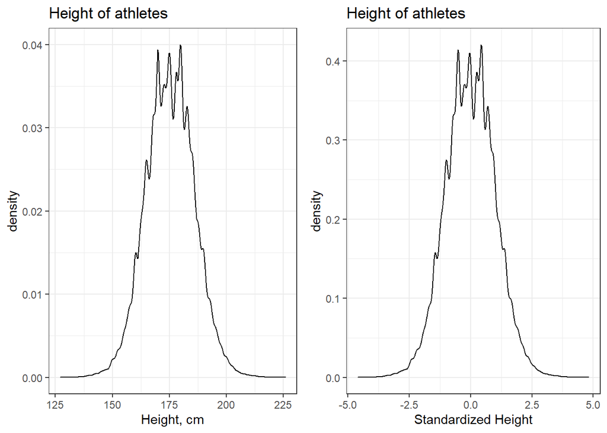

### The Height variable min-max standardization

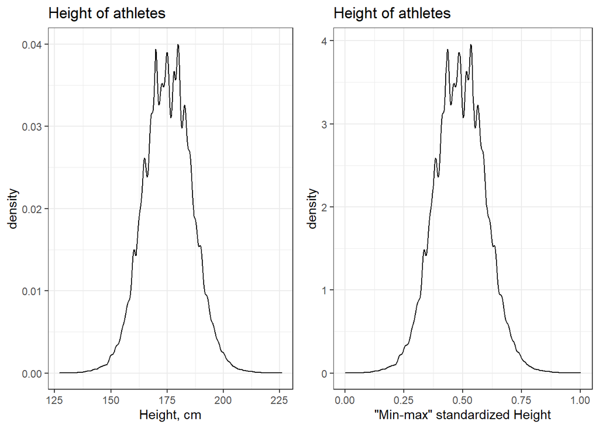

# Olympic statistics

## Youngest at the 1992 Olympics

Age of the youngest athletes at the 1992 Olympics is **11** years for men, and **12** years for women.

## Mean and standard deviation of Height variable

For men Height variable has **mean = 179.73** with **standard deviation = 9.46**.

For women Height variable has **mean = 169.19** with **standard deviation = 8.46**.

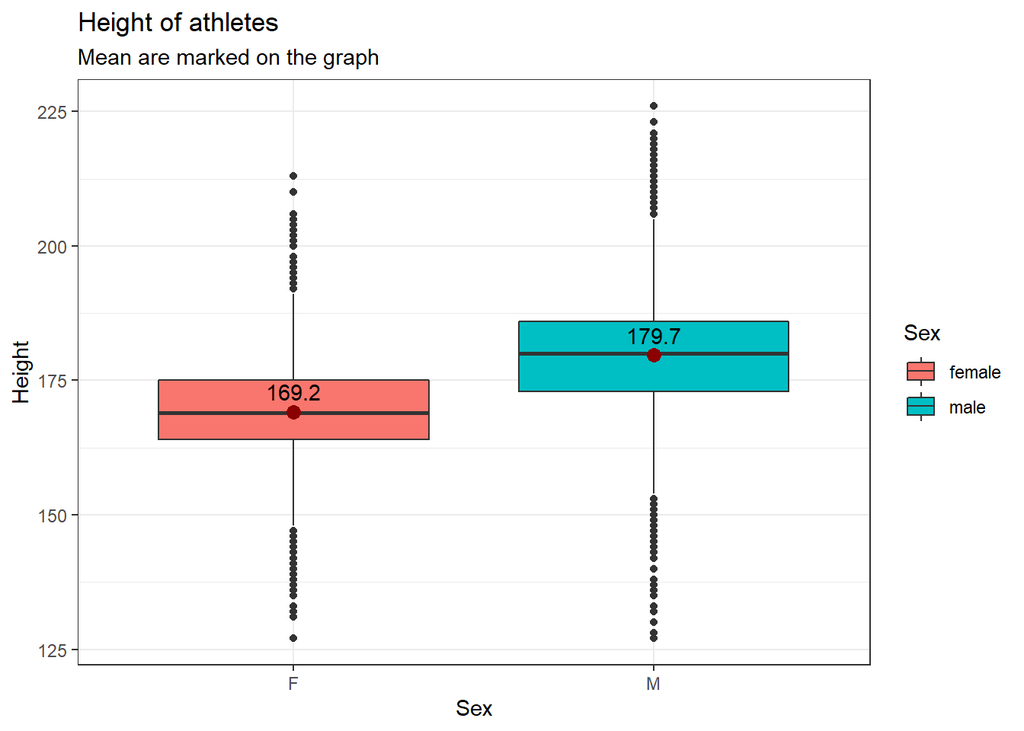

### Mean and standard deviation of Height variable for female tennis players at the 2000 Games

For women tennis players Height variable has **mean = 171.8** with **standard deviation = 6.6** at the 2000 Olympics.

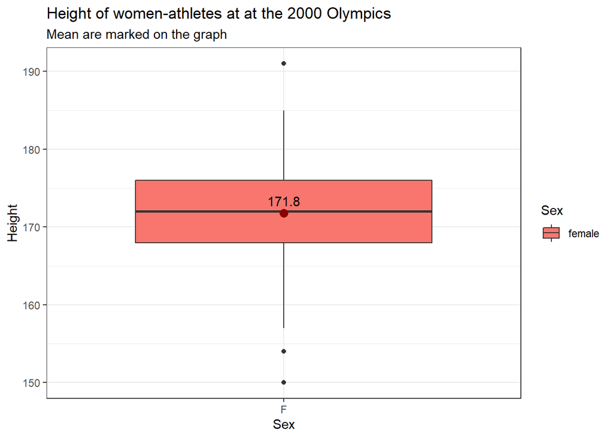

## Heaviest athlete in the 2006 Olympics

The heaviest athlete in the 2006 Olympics participated in the **Skeleton** and had weight 127 kg.

## Gold medals received by women from 1980 to 2010

Women received **2249 gold medals** from 1980 to 2010.

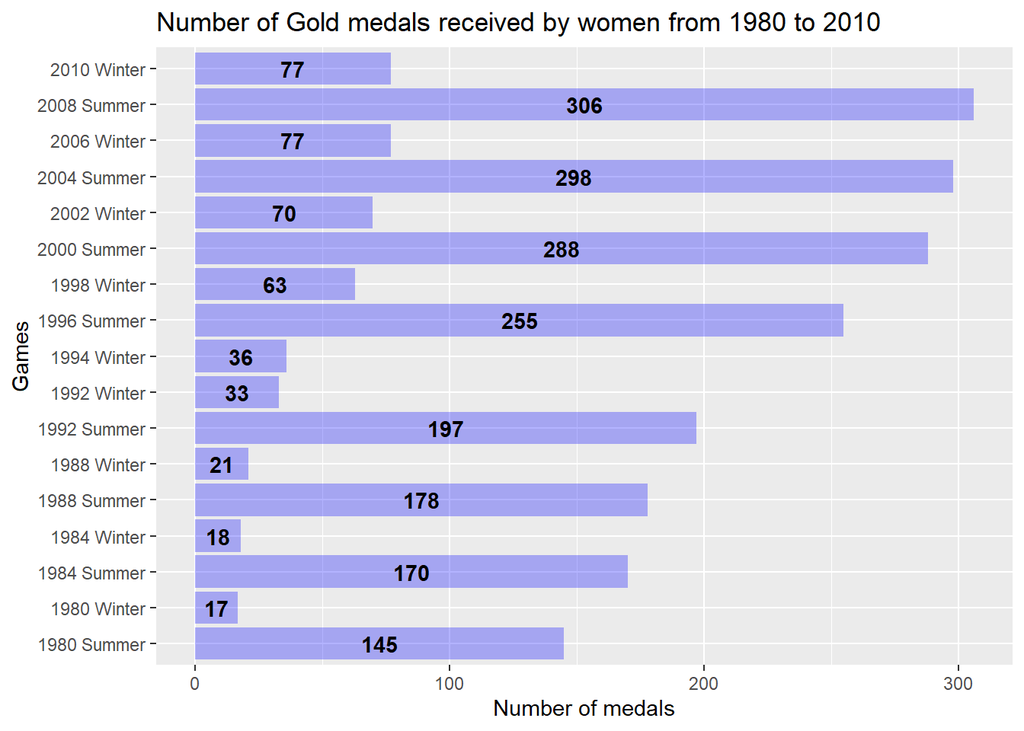

## Number of participation times of athlete John Aalberg in the Olympic Games

| Year | Name | Games | Country_NOC | Number of Participations |
| --- | --- | --- | --- | --- |
| 1992 | John Aalberg | 1992 Winter | United States | 4 |
| 1994 | John Aalberg | 1994 Winter | United States | 4 |

John Aalberg participated in Olympic games 8 times, 4 times in the 1992 Winter Games and 4 times in the 1994 Winter Games.

## Age groups of participants in the 2008 Olympic Games

The following boundaries were used to divide the participants into groups:  
- group 0: Age < 15;  
- group 1: Age 15-24;  
- group 2: Age 25-34;  
- group 3: Age 35-44;  
- group 4: Age 45-55;  
- group 5: Age > 55.

Each participant was counted only once, according to their ID number.

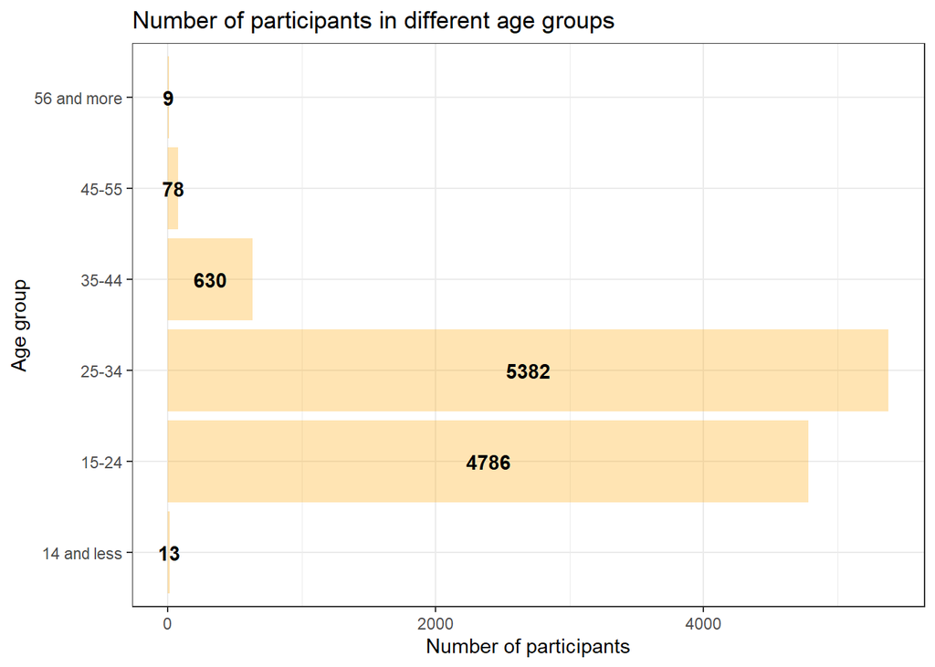

Among the participants from 15 to 55 years old, the smallest group is the 45-55 age group, the most numerous is the 25-34 age group.

## Сhanging of the number of sports in the 2002 Olympics from the 1994 Olympic

The Olympic Games in 1994 and 2002 are the Winter Olympics. From 1994 to 2002, the number of Olympic winter sports increased.

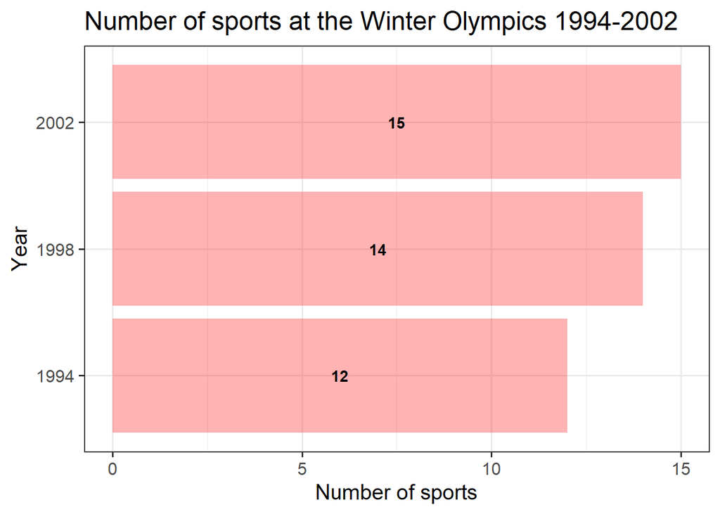

The number of sports in 1994 was 12. The number of sports in 2002 was 15.

The number of sports at the 2002 Olympics, compared to 1994, has **increased by 3 sports, or 25%**.

## Top countries for each type of medal for the winter and summer Olympiads separately

### Winter Games

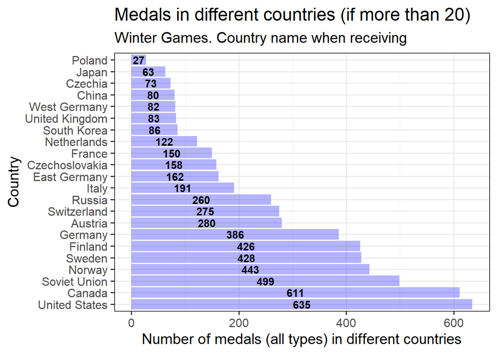

Top 3 countries with the most Gold medals in Winter games:

| Country_NOC | Gold_Medals |
| --- | --- |
| Canada | 305 |
| Soviet Union | 285 |
| United States | 166 |

Top 3 countries with the most Silver medals in Winter games:

| Country_NOC | Silver_Medals |
| --- | --- |
| United States | 308 |
| Canada | 199 |
| Norway | 165 |

Top 3 countries with the most Bronze medals in Winter games:

| Country_NOC | Bronze_Medals |
| --- | --- |
| Finland | 215 |
| Sweden | 177 |
| United States | 161 |

### Summer Games

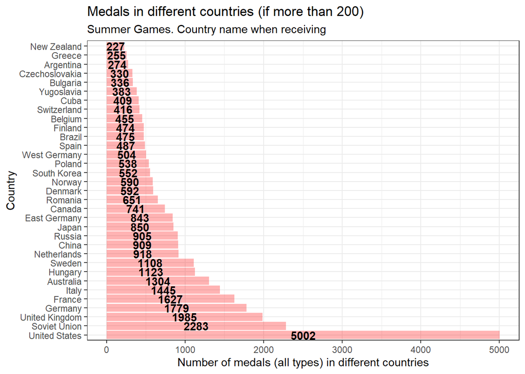

*Medals won by the Unified Team in the 1992 Olympics counted as medals of the Soviet union*.

| Country_NOC | Gold_Medals |
| --- | --- |
| United States | 2472 |
| Soviet Union | 924 |
| United Kingdom | 636 |

| Country_NOC | Silver_Medals |
| --- | --- |
| United States | 1333 |
| United Kingdom | 729 |
| Soviet Union | 696 |

| Country_NOC | Bronze_Medals |
| --- | --- |
| United States | 1197 |
| Soviet Union | 663 |
| Germany | 649 |

## Comparisons and hypotheses

### Comparsion of the height, weight and ages of men and women who competed in the Winter Olympics

Sample size large enough to treat the distribution of height, weight and age as normally distributed values.

Each athlete is counted only once for each Games.

#### Height comparison

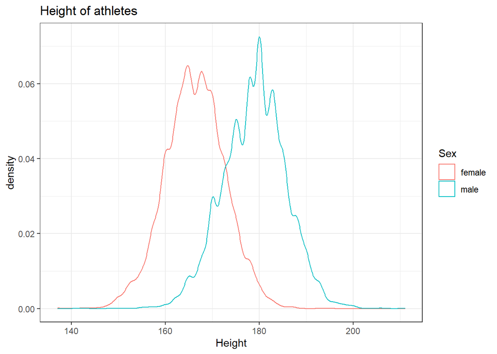

Welch Two Sample t-test (two sided) was performed. Alternative hypothesis - the athletes height depends on the sex.

The value of the t-statistic is **-138.876** with **14445.2** degrees of freedom.  
Welch Two Sample t-test showed that there was a significant difference between the male athletes height compared with female athletes height (p-value = **0 < 2.2 * 10^-16** ).

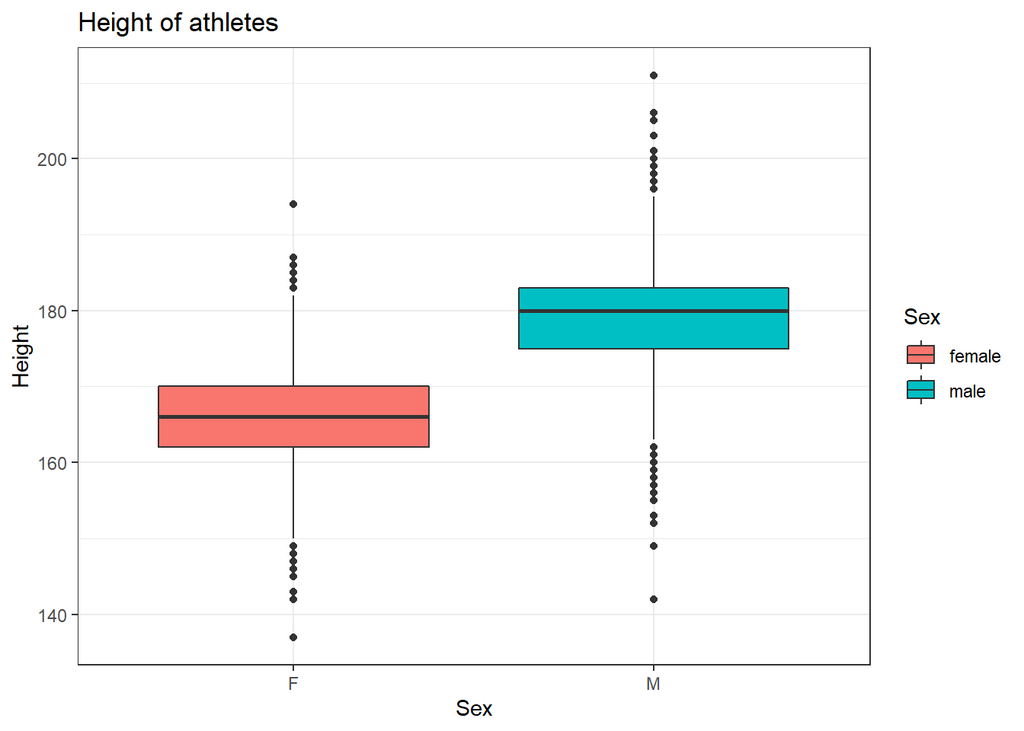

#### Weight comparison

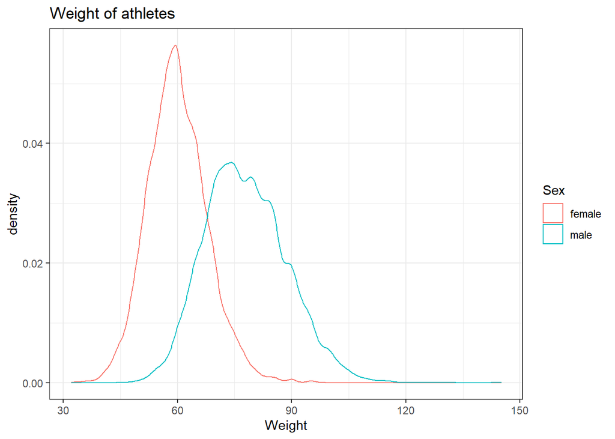

Welch Two Sample t-test (two sided) was performed. Alternative hypothesis - the athletes weight depends on the sex.

The value of the t-statistic is **-142.817** with **17998.9** degrees of freedom.  
Welch Two Sample t-test showed that there was a significant difference between the male athletes weight compared with female athletes weight (p-value = **0 < 2.2 * 10^-16** ).

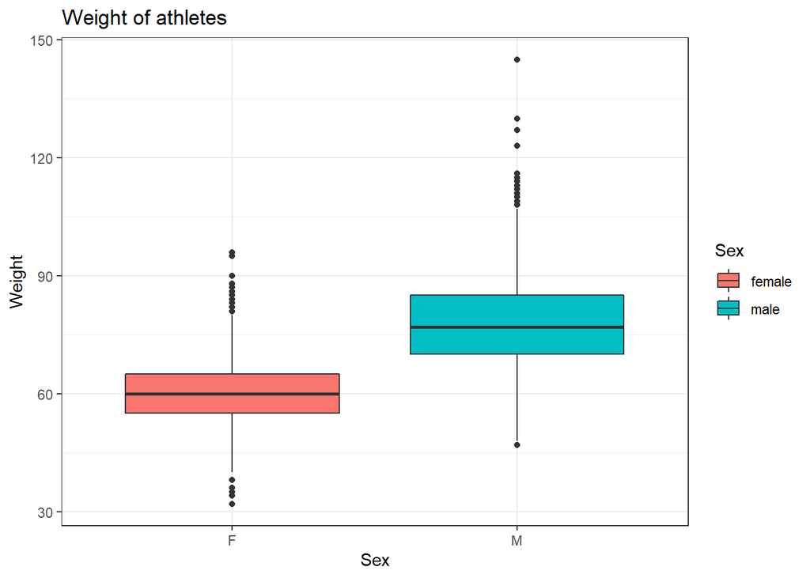

#### Age comparison

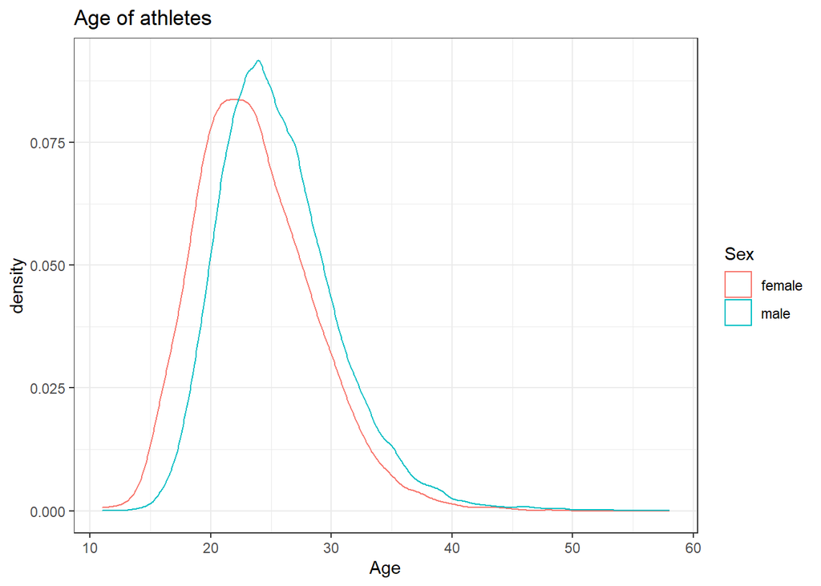

Welch Two Sample t-test (two sided) was performed. Alternative hypothesis - the athletes age depends on the sex.

The value of the t-statistic is **-30.221** with **14747.7** degrees of freedom.  
Welch Two Sample t-test showed that there was a significant difference between the male athletes age compared with female athletes age (p-value = **1.033492^{-194} < 2.2 * 10^-16** ).

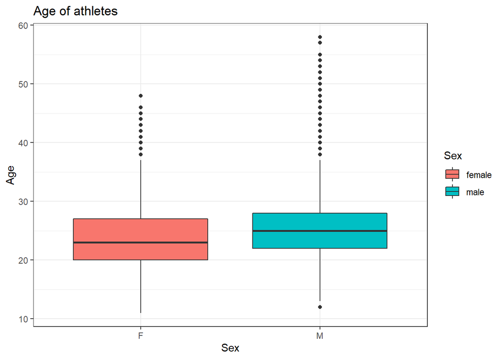

### Do we have any reason to believe that variables Team and Medal might be interrelated?

#### Some information about Team and Medal

The number of teams (countries) participating in the Olympic Games from 1896 to 2016 is 230.

Team has an average of 49 participants (with a standard deviation of 82.05) yearly.

Each team won an average of 10.36 medals of any type (with a standard deviation of 30.34) yearly.

During the observation period, each team received an average of 172.97 medals (with a standard deviation of 537.58).

#### Correlation

Hypothesis - there is a relationship between the team and the number of medals through the size of the team, that is, there is a relationship between the size of a team and the number of medals it won.

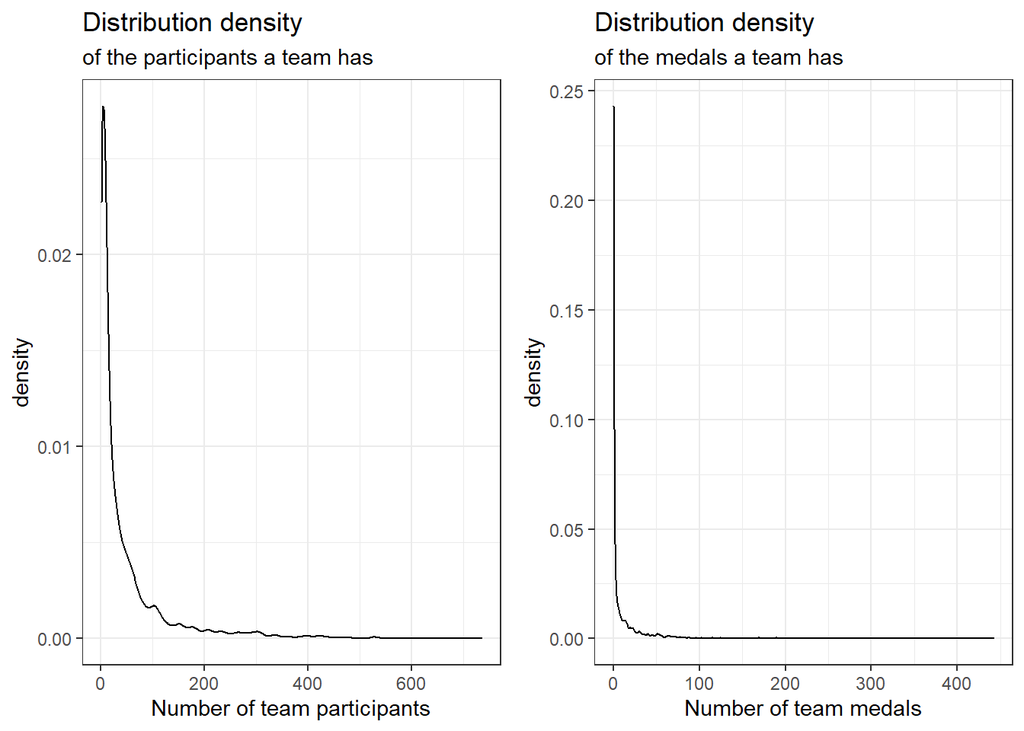

A matrix of scatterplots for team members and number medals:

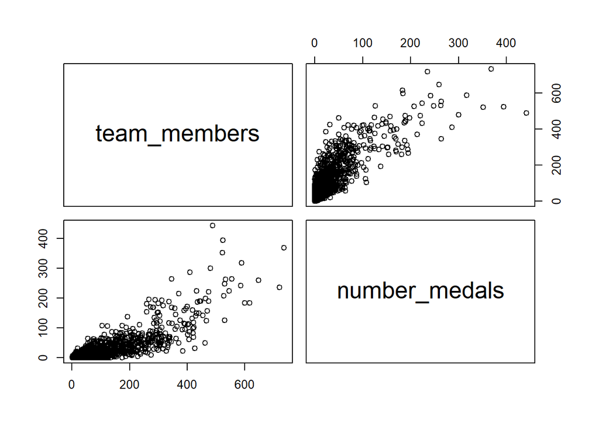

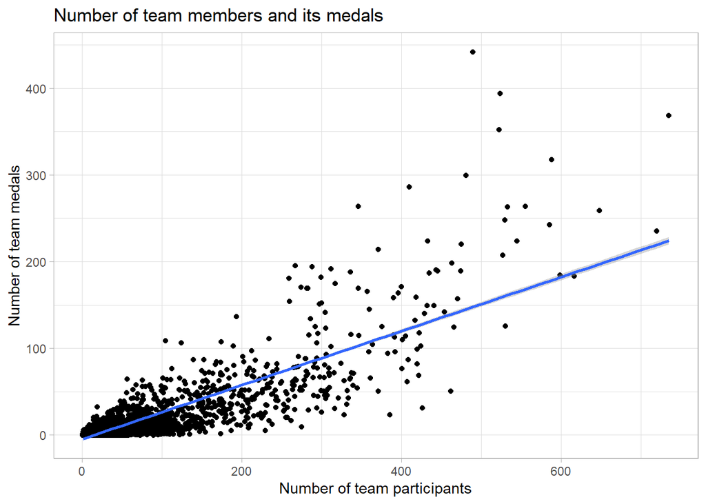

Kendall’s correlation. The Kendall’s rank correlation tau tests the null hypothesis ‘There is no correlation between the number of participants in team and the number of team medals’.

A Kendall’s rank correlation tau test showed that there is a marked degree of positive correlation (z = **53.077**, tau = **0.64**, and p = **0** < 2.2 * 10^(-16)) between the number of team members and the number of team medals.

Below are the top 10 countries with the largest average team size.

| Country_NOC | average_team_size |
| --- | --- |
| United States | 257 |
| Soviet Union | 227 |
| Russia | 222 |
| West Germany | 201 |
| Germany | 197 |
| United Kingdom | 166 |
| France | 162 |
| China | 157 |
| East Germany | 156 |
| Ukraine | 140 |

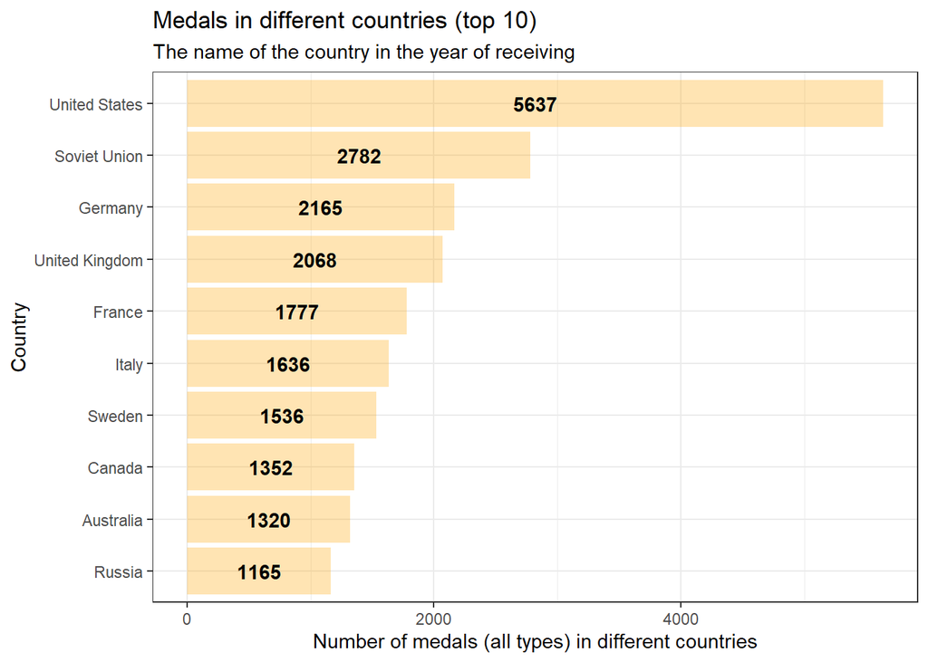

#### Correlation for diffrenet medal types

The same correlation analysis was performed for Gold, Silver, Bronze and “No medal” medals separately.

##### Gold medals

Hypothesis - there is a relationship between the team and the number of Gold medals through the size of the team, that is, there is a relationship between the size of a team and the number of Gold medals it won.

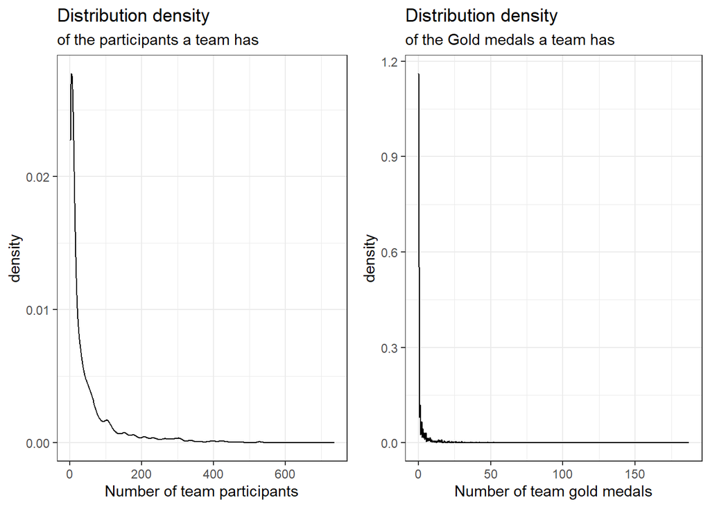

The number of participants in a team and the number of a team gold medals - do not have a normal distribution. Shapiro-Wilk normality test for p-value = 0 < 2.2 * 10^(-16) for team members distribution (with W = 0.598 and and the number of observations - 3841), and p-value = 0 < 2.2 * 10^(-16) for team medals distribution (with W = 0.29 and the number of observations - 3841).

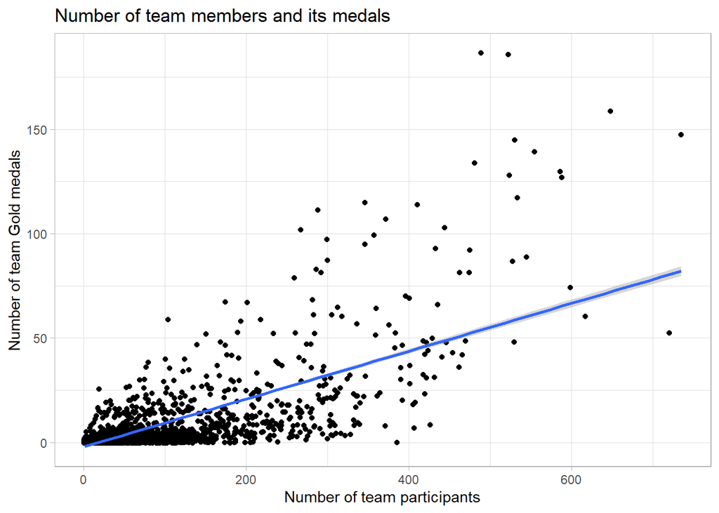

Kendall’s correlation. The Kendall’s rank correlation tau tests the null hypothesis ‘There is no correlation between the number of participants in team and the number of team Gold medals’.

A Kendall’s rank correlation tau test showed that there is a marked degree of positive correlation (z = **43.141**, tau = **0.54**, and p = **0**< 2.2 * 10^(-16)) between the number of team members and the number of team Gold medals.

##### Silver medals

Hypothesis - there is a relationship between the team and the number of Silver medals through the size of the team, that is, there is a relationship between the size of a team and the number of Silver medals it won.

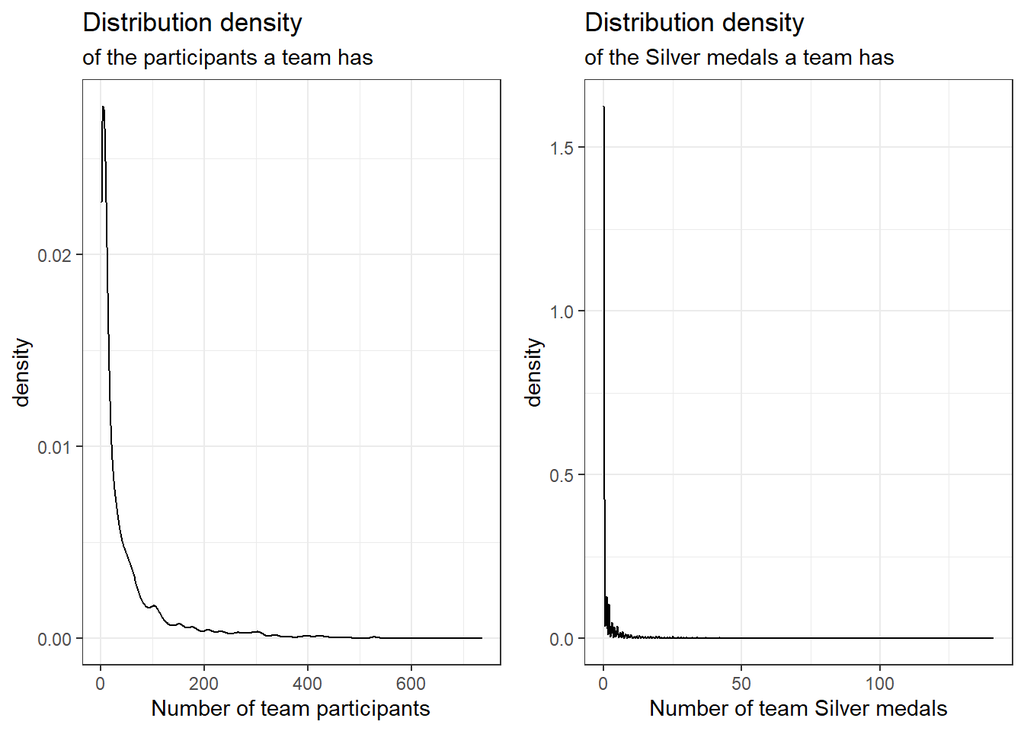

The number of participants in a team and the number of a team Silver medals - do not have a normal distribution. Shapiro-Wilk normality test for p-value = 0 < 2.2 * 10^(-16) for team members distribution (with W = 0.598 and the number of observations - 3841), and p-value = 0 < 2.2 * 10^(-16) for team medals distribution (with W = 0.372 and the number of observations - 3841).

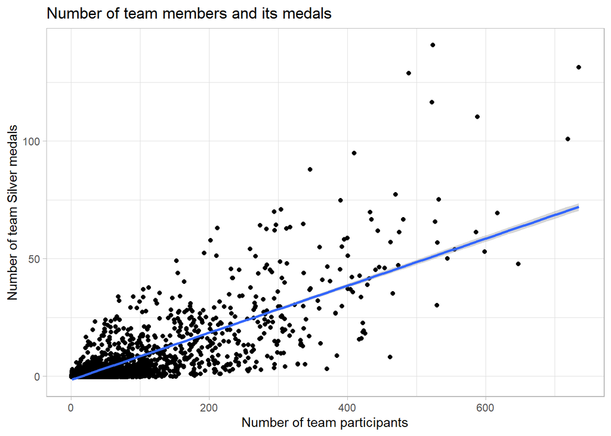

Kendall’s correlation. The Kendall’s rank correlation tau tests the null hypothesis ‘There is no correlation between the number of participants in team and the number of team Silver medals’.

A Kendall’s rank correlation tau test showed that there is a marked degree of positive correlation (z = **46.698**, tau = **0.58**, and p = **0** < 2.2 * 10^(-16)) between the number of team members and the number of team Silver medals.

##### Bronze medals

Hypothesis - there is a relationship between the team and the number of Bronze medals through the size of the team, that is, there is a relationship between the size of a team and the number of Bronze medals it won.

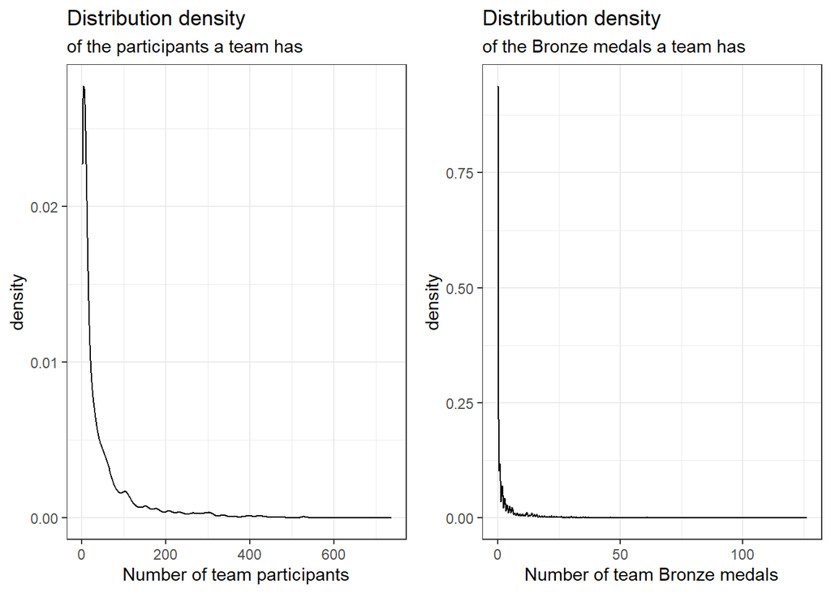

The number of participants in a team and the number of a team Bronze medals - do not have a normal distribution. Shapiro-Wilk normality test for p-value = 0 < 2.2 * 10^(-16) for team members distribution (with W = 0.598 and the number of observations - 3841), and p-value = 0 < 2.2 * 10^(-16) for team medals distribution (with W = 0.4 and the number of observations - 3841).

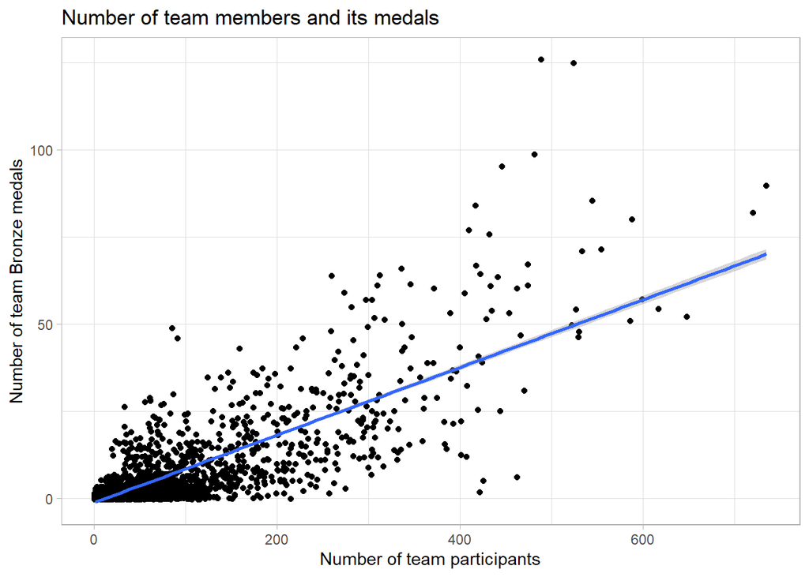

Kendall’s correlation. The Kendall’s rank correlation tau tests the null hypothesis ‘There is no correlation between the number of participants in team and the number of team Bronze medals’.

A Kendall’s rank correlation tau test showed that there is a marked degree of positive correlation (z = **48.069**, tau = **0.59**, and p = **0** < 2.2 * 10^(-16)) between the number of team members and the number of team Bronze medals.

##### No medals

Hypothesis - there is a relationship between the team and the number of participants without medals through the size of the team, that is, there is a relationship between the size of a team and the number of medals it not won.

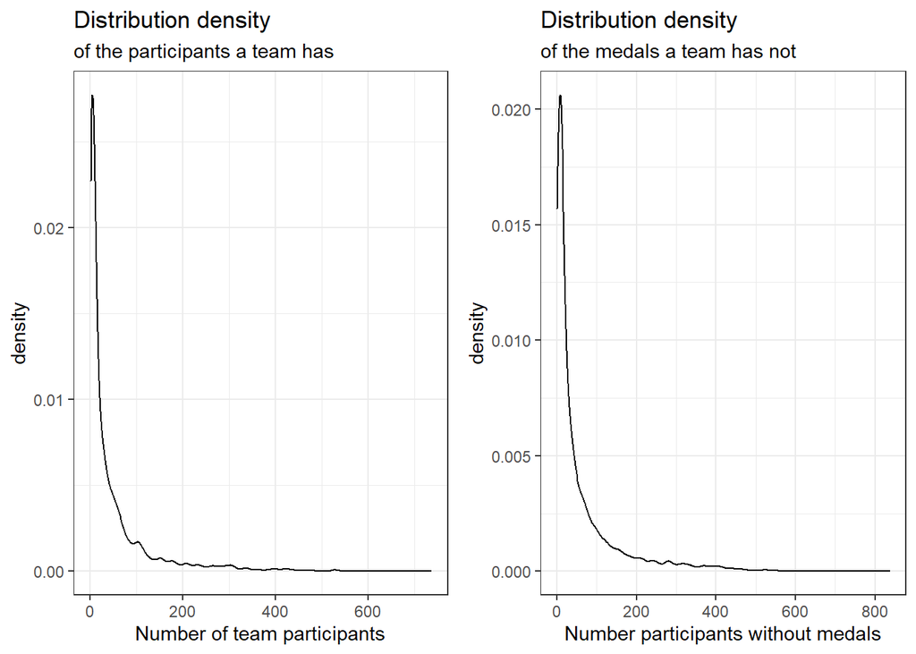

The number of participants in a team and the number of a team participants without medals - do not have a normal distribution. Shapiro-Wilk normality test for p-value = 0 < 2.2 * 10^(-16) for team members distribution (with W = 0.598 and the number of observations - 3841), and p-value = 0 < 2.2 * 10^(-16) for team participants without medals distribution (with W = 0.651 and the number of observations - 3841).

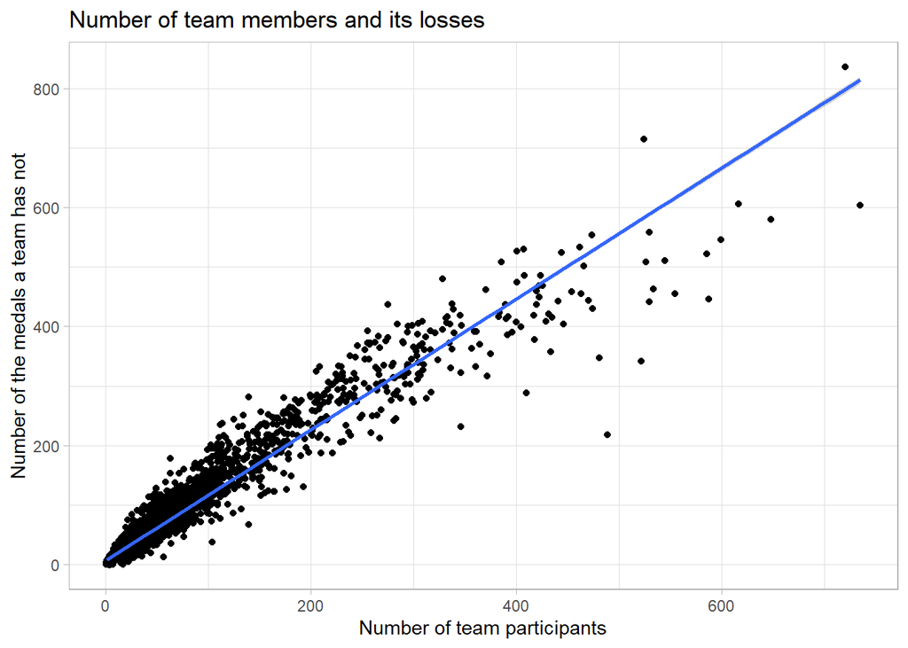

The Kendall’s rank correlation tau tests the null hypothesis ‘There is no correlation between the number of participants in team and the number of team losses’.

A Kendall’s rank correlation tau test showed that there is a strong positive correlation (z = **81.232**, tau = **0.89**, and p = **0** < 2.2 * 10^(-16)) between the number of team members and the number of their losses.

#### Medals per participant

To study the average number of medals received by each team each year without the influence of team size, we can calculate the average ratio of medals received to team size for each team.

Top 20 countries with the most medals per competitor:

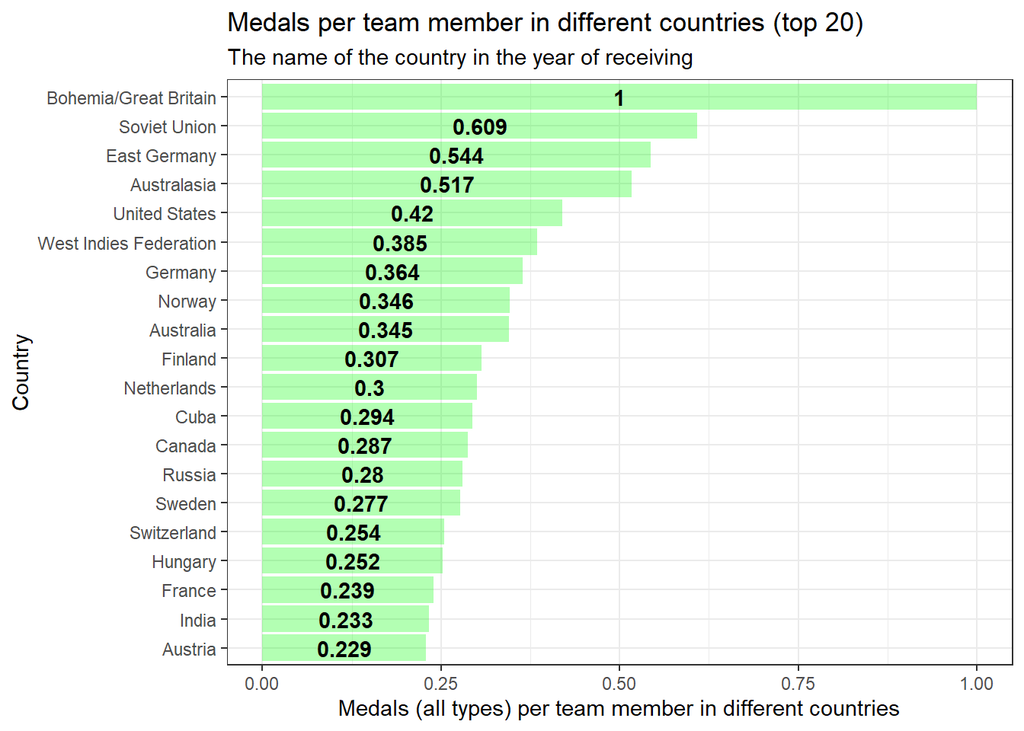

For all types of medals, the average number of medals per participant per country is 0.0684 (standard deviation 0.1199).

##### Gold medals per team member

Top 20 countries with the most Gold medals per competitor:

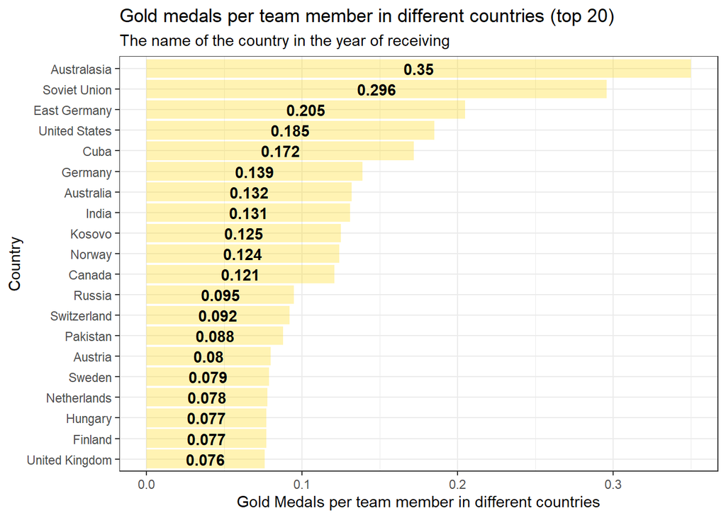

For Gold medals, the average number of medals per participant per country is 0.0202 (standard deviation 0.0445).

##### Silver medals per team member

Top 20 countries with the most Silver medals per competitor:

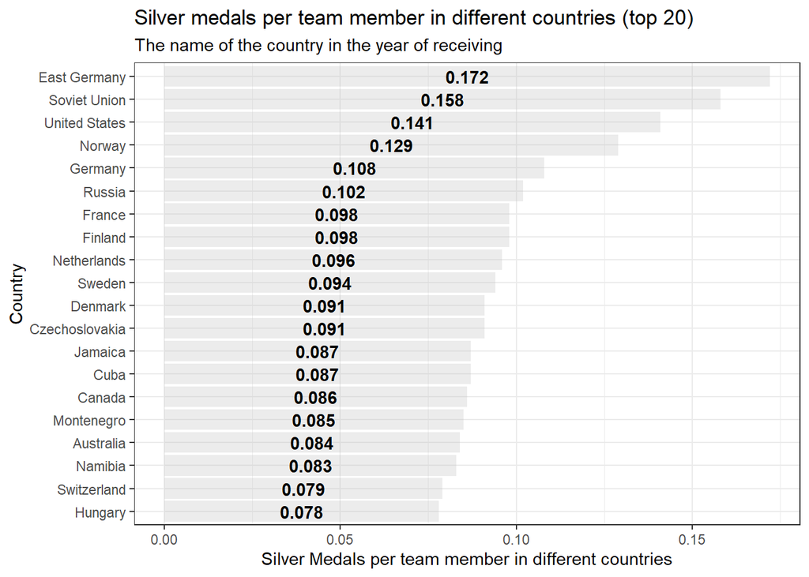

For Silver medals, the average number of medals per participant per country is 0.0198 (standard deviation 0.0321).

##### Bronze medals per team member

Top 20 countries with the most bronze medals per competitor:

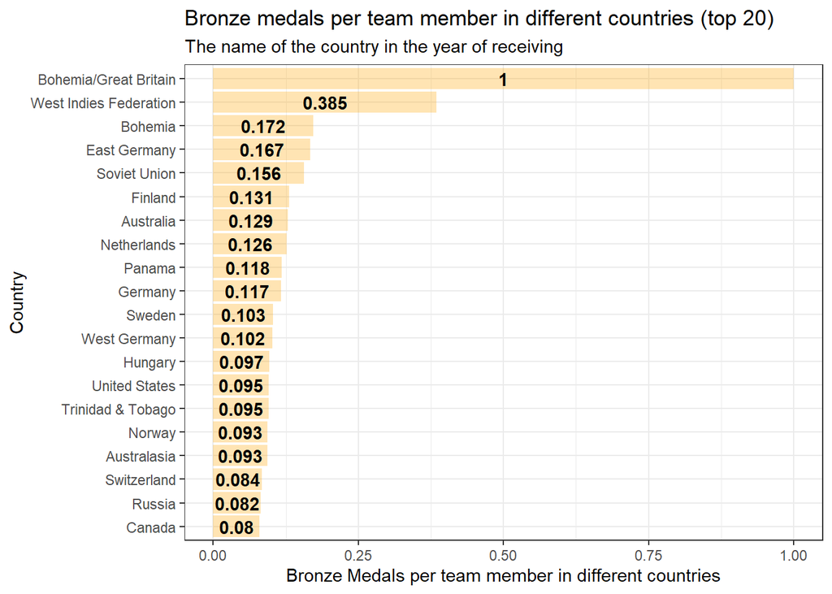

For Bronze medals, the average number of medals per participant per country is 0.0281 (standard deviation 0.0765).